### Downloading and visualizing data from TCGA database using TCGAbiolinks package

### Introduction

This R workflow will download and visualize Transcription Profiling and Single Nucleotide Mutation data from the Colon Adenocarcinoma (TCGA-COAD) project using the `TCGAbiolinks` package.

### Setup

As in a regular R script in RStudio, a single line of code can be run with Command-Enter (Mac OS) or Ctrl-Enter (Windows). Whole chunks of code can be run with Command(/Ctrl) + Shift + Enter **or** by clicking the green “>” button in the top-right corner of the chunk. Alternatively, these options can also be implemented by selecting lines of code and choosing the desired option from the drop-down menu in the “Run” tab, in the top-right corner of the of Source section of RStudio.

To comment or uncomment a series of lines, highlight the lines and use Command(/Ctrl) + Shift + C.

R packages `CGAbiolinks`, `tidyverse`, `maftools`, `pheatmap`, `SummarizedExperiment`, `sesame`, and `sesameData` are required for this workflow.

They can be installed using the following commands:

```r
#install.packages("TCGAbiolinks")
#install.packages("tidyverse")
#install.packages("maftools")
#install.packages("pheatmap")
#install.packages("SummarizedExperiment")
#install.packages("sesame")
#install.packages("sesameData")

# If install.packages("packagename") command fails in newer versions of R uncomment and run the commands:
# if (!require("BiocManager", quietly = TRUE))
#    install.packages("BiocManager")
# BiocManager::install("packagename")
```

Once installed, load the packages.

```r
library(TCGAbiolinks)
library(tidyverse)
```

```r
library(maftools)
library(pheatmap)
library(SummarizedExperiment)
library(sesame)
library(sesameData)
```

### Build a query for expression data

```r
# obtain the list of projects

gdcprojects <- getGDCprojects()
#View(gdcprojects)

getProjectSummary('TCGA-COAD')
```

```
## $file_count
## [1] 25726
##
## $data_categories
##    file_count case_count                data_category
## 1        7565        461  Simple Nucleotide Variation
## 2        3607        460             Sequencing Reads
## 3        2835        461                  Biospecimen
## 4         995        461                     Clinical
## 5        5344        460        Copy Number Variation
## 6        1978        459      Transcriptome Profiling
## 7        1665        457              DNA Methylation
## 8         363        360           Proteome Profiling
## 9          46         23 Somatic Structural Variation
## 10       1328        289         Structural Variation
##
## $case_count
## [1] 461
##
## $file_size
## [1] 2.737511e+14
```

```r
# build a query to select COAD expression data

query_TCGA <- GDCquery(project  = 'TCGA-COAD',
                  data.category = 'Transcriptome Profiling')
```

```
## o GDCquery: Searching in GDC database
```

```
## Genome of reference: hg38
```

```
## oo Accessing GDC. This might take a while...
```

```
## ooo Project: TCGA-COAD
```

```
## oo Filtering results
```

```
## oo Checking data
```

```
## ooo Checking if there are duplicated cases
```

```
## ooo Checking if there are results for the query
```

```
## o Preparing output
```

```r
#View(query_TCGA)

output_query_TCGA <- getResults(query_TCGA)
#View(output_query_TCGA)
```

### Retrieve gene expression data

```r
# build a query to retrieve gene expression data

query_TCGA <- GDCquery(project  = 'TCGA-COAD', data.category = 'Transcriptome Profiling', experimental.strategy = 'RNA-Seq',
                       workflow.type = 'STAR - Counts', access = 'open',
                       barcode = c('TCGA-AA-3692-01A-01R-0905-07',
                                   'TCGA-AA-3662-11A-01R-1723-07',
                                   'TCGA-AA-A00L-01A-01R-A002-07'))
```

```
## o GDCquery: Searching in GDC database
```

```
## Genome of reference: hg38
```

```
## oo Accessing GDC. This might take a while...
```

```
## ooo Project: TCGA-COAD
```

```
## oo Filtering results
```

```
## ooo By access
```

```
## ooo By experimental.strategy
```

```
## ooo By workflow.type
```

```
## ooo By barcode
```

```
## oo Checking data
```

```
## ooo Checking if there are duplicated cases
```

```
## ooo Checking if there are results for the query
```

```
## o Preparing output
```

```r
getResults(query_TCGA)
```

```
##                                     id data_format                        cases
## 1 534054c8-b88f-4b5f-b718-f4ca8484b83c         TSV TCGA-AA-3692-01A-01R-0905-07
## 2 c63c52c9-82ba-46f8-bd0c-9459f25e98f2         TSV TCGA-AA-3662-11A-01R-1723-07
## 3 82aa9226-61c4-4cd7-9138-5199e7c85e6a         TSV TCGA-AA-A00L-01A-01R-A002-07
##   access
## 1   open
## 2   open
## 3   open
##                                                                     file_name
## 1 4d33ae3d-d6e6-47cd-bb5d-52134a7bcf8d.rna_seq.augmented_star_gene_counts.tsv
## 2 ed61dd33-6f80-4998-a0fb-82498e123505.rna_seq.augmented_star_gene_counts.tsv
## 3 e0c9f612-91a0-4b84-b3d5-665514324cb6.rna_seq.augmented_star_gene_counts.tsv
##                           submitter_id           data_category            type
## 1 cf853c78-c86f-4711-af16-1fb9013eb90f Transcriptome Profiling gene_expression
## 2 80de6ed8-a882-4bb4-a052-5688ab507bba Transcriptome Profiling gene_expression
```

[output cut: 37 more lines]

### Download selected expression data

```r
# download selected expression data -- GDCdownload

GDCdownload(query_TCGA)
```

```
## Of the 3 files for download 3 already exist.
```

```
## All samples have been already downloaded
```

```r
# prepare the queried data

tcga_coad_data <- GDCprepare(query_TCGA, summarizedExperiment = TRUE)
```

```
## Starting to add information to samples
```

```
##  => Add clinical information to samples
```

```
##  => Adding TCGA molecular information from marker papers
```

```
##  => Information will have prefix 'paper_'
```

```
## coad subtype information from:doi:10.1038/nature11252
```

```
## Available assays in SummarizedExperiment :
##   => unstranded
##   => stranded_first
##   => stranded_second
##   => tpm_unstrand
##   => fpkm_unstrand
##   => fpkm_uq_unstrand
```

```r
coad_matrix <- assay(tcga_coad_data, 'unstranded')
#View(coad_matrix)
```

```r
# to get the FPKM dataset

coad_matrix <- assay(tcga_coad_data, 'fpkm_unstrand')
#View(coad_matrix)
```

### Build a query for mutation data

```r
# build a query for mutation data

query_TCGA <- GDCquery(project  = 'TCGA-COAD',
                       data.category = 'Simple Nucleotide Variation')
```

```
## o GDCquery: Searching in GDC database
```

```
## Genome of reference: hg38
```

```
## oo Accessing GDC. This might take a while...
```

```
## ooo Project: TCGA-COAD
```

[output not shown]

```
## We will retry to access GDC!
```

```
## oo Filtering results
```

```
## oo Checking data
```

```
## ooo Checking if there are duplicated cases
```

```
## ooo Checking if there are results for the query
```

```
## o Preparing output
```

```r
#View(query_TCGA)
```

```r
# query and visualize selected mutation data

query_mutation <- GDCquery(project = 'TCGA-COAD',
                           data.category = 'Simple Nucleotide Variation',
                           access = 'open',
                           barcode = c('TCGA-AA-3662-01A-01D-1719-10,TCGA-AA-3662-11A-01D-1719-10',
                                        'TCGA-G4-6314-01A-11D-1719-10,TCGA-G4-6314-10A-01D-1720-10'))
```

```
## o GDCquery: Searching in GDC database
```

```
## Genome of reference: hg38
```

```
## oo Accessing GDC. This might take a while...
```

```
## ooo Project: TCGA-COAD
```

```
## oo Filtering results
```

```
## ooo By access
```

```
## ooo By barcode
```

```
## oo Checking data
```

```
## ooo Checking if there are duplicated cases
```

```
## ooo Checking if there are results for the query
```

```
## o Preparing output
```

```r
output_query_mutation <- getResults(query_mutation)
#View(output_query_mutation)
```

### Download selected mutation data

```r
# download selected  data

GDCdownload(query_mutation)
```

```
## Of the 2 files for download 2 already exist.
```

```
## All samples have been already downloaded
```

### Create a dashboard and an oncoplot

```r
# maftools utilities to read and create dashboard

maf <- GDCprepare(query_mutation, summarizedExperiment = TRUE)
```

[output not shown]

```r
maftools.input <- read.maf(maf)
```

```
## -Validating
## -Silent variants: 63
## -Summarizing
## -Processing clinical data
## --Missing clinical data
## -Finished in 0.032s elapsed (0.030s cpu)
```

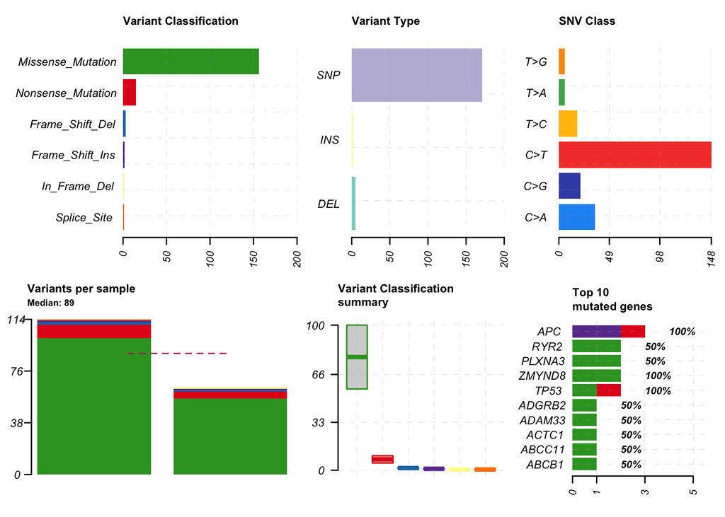

```r
# create a dashboard

plotmafSummary(maf = maftools.input,
               addStat = 'median',
               rmOutlier = TRUE,
               dashboard = TRUE)
```

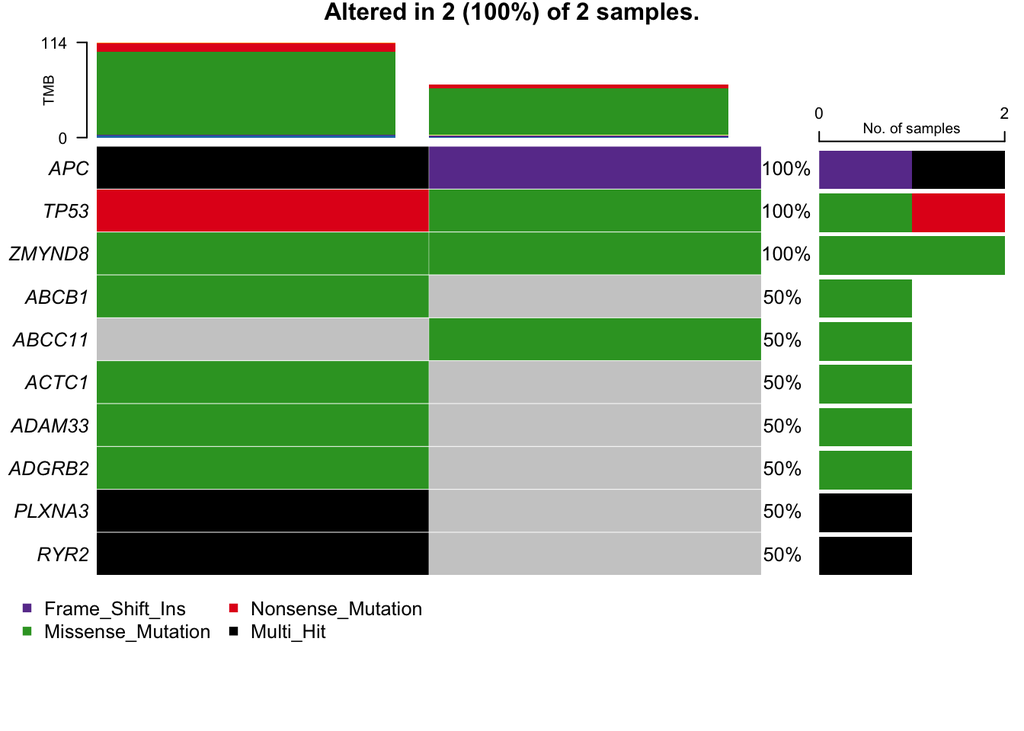

```r
# createan oncoplot

oncoplot(maf = maftools.input,
         top = 10,
         removeNonMutated = TRUE)
```